# marketing_homework_4

2025-02-19

**EXPLANATION OF EXPONENTS:**

- **Own‐price elasticity (Brand i’s volume/share vs. Brand i’s price): negative.**
- **Cross‐price elasticity (Brand i’s volume/share vs. Brand j’s price): positive for substitutes.**

**In your sales model, you included all 7 brand prices in the same equation for brand i’s log sales. That should give negative for brand i’s own LPRICEᵢ, positive for the others. But you found negative cross‐price estimates. That is the sign that something is “wrong” in the sense of collinearity or mis‐specification:**

- **It’s not that your “own‐price model is wrong.” Actually, the negative own‐price effect is correct.**
- **The issue is that the cross‐price effects are also going negative, which doesn’t make sense for substitutable brands. That’s the part your professor flags as a red flag for collinearity.**

**Own‐price elasticity should be negative:**

- Economically, raising a brand’s own price causes its own demand (or share) to go down.
- So if brand A’s price goes up, brand A’s volume (or share) goes down → hence the expected negative coefficient for brand A’s own price.

**Cross‐price elasticity should be positive (for substitutes):**

- If you raise a competitor brand’s price, demand for your brand should go up (assuming the products compete and are substitutes).
- So if brand B raises its price, brand A’s volume (or share) typically should go up → hence a positive coefficient on brand B’s price in brand A’s equation.

```r
library("bayesm")
data(tuna)
print(tuna)
```

[output not shown]

[output cut: 1680 more lines]

$WEEK a numeric vector$MOVE unit sales of brand # $NSALE a measure of display activity of brand #$LPRICE log of price of brand # $LWHPRIC log of wholesale price of brand #$FULLCUST total customers visits

```r
ls(tuna)
```

```
##  [1] "FULLCUST" "LPRICE1"  "LPRICE2"  "LPRICE3"  "LPRICE4"  "LPRICE5"
##  [7] "LPRICE6"  "LPRICE7"  "LWHPRIC1" "LWHPRIC2" "LWHPRIC3" "LWHPRIC4"
## [13] "LWHPRIC5" "LWHPRIC6" "LWHPRIC7" "MOVE1"    "MOVE2"    "MOVE3"
## [19] "MOVE4"    "MOVE5"    "MOVE6"    "MOVE7"    "NSALE1"   "NSALE2"
## [25] "NSALE3"   "NSALE4"   "NSALE5"   "NSALE6"   "NSALE7"   "WEEK"
```

# Price elasticity

```r
# Define the column names for sales and prices
n_brands <- 7
sales_cols <- paste0("MOVE", 1:n_brands)
price_cols <- paste0("LPRICE", 1:n_brands)
```

```r
models <- list()

for(i in 1:n_brands) {
  # Build a formula: log(NSALEi) ~ LPRICE1 + LPRICE2 + ... + LPRICE7
  formula_str <- paste0("log(", sales_cols[i], ") ~ ", paste(price_cols, collapse = " + "))

  # Fit the model using lm()
  models[[i]] <- lm(as.formula(formula_str), data = tuna)

  cat("\n------ Model for Brand", i, "------\n")
  print(summary(models[[i]]))
}
```

```
##
## ------ Model for Brand 1 ------
##
## Call:
## lm(formula = as.formula(formula_str), data = tuna)
##
## Residuals:
##     Min      1Q  Median      3Q     Max
## -2.1092 -0.2666 -0.0915  0.1706  3.2151
##
## Coefficients:
##             Estimate Std. Error t value Pr(>|t|)
## (Intercept)   9.0591     1.2485   7.256 2.87e-12 ***
## LPRICE1      -4.4352     0.2106 -21.056  < 2e-16 ***
## LPRICE2       0.6561     0.2107   3.114  0.00201 **
## LPRICE3      -0.1211     0.6285  -0.193  0.84738
## LPRICE4       1.1208     0.1837   6.102 2.94e-09 ***
## LPRICE5       1.0210     0.5815   1.756  0.08006 .
## LPRICE6      -0.2238     1.0733  -0.208  0.83499
## LPRICE7       0.5720     0.2628   2.176  0.03023 *
## ---
## Signif. codes:  0 '***' 0.001 '**' 0.01 '*' 0.05 '.' 0.1 ' ' 1
##
## Residual standard error: 0.4889 on 330 degrees of freedom
## Multiple R-squared:  0.5798, Adjusted R-squared:  0.5709
## F-statistic: 65.05 on 7 and 330 DF,  p-value: < 2.2e-16
##
##
## ------ Model for Brand 2 ------
##
## Call:
## lm(formula = as.formula(formula_str), data = tuna)
##
## Residuals:
##     Min      1Q  Median      3Q     Max
## -1.2650 -0.2874 -0.0681  0.1918  3.4332
##
## Coefficients:
##             Estimate Std. Error t value Pr(>|t|)
## (Intercept)  8.25388    1.28540   6.421 4.71e-10 ***
```

[output cut: 133 more lines]

```
##             Estimate Std. Error t value Pr(>|t|)
## (Intercept) 12.54294    1.50036   8.360 1.78e-15 ***
## LPRICE1      1.05851    0.25312   4.182 3.71e-05 ***
## LPRICE2      0.07106    0.25322   0.281 0.779170
## LPRICE3      0.87155    0.75532   1.154 0.249385
## LPRICE4     -0.06797    0.22073  -0.308 0.758324
## LPRICE5      0.76768    0.69878   1.099 0.272748
## LPRICE6     -4.32011    1.28982  -3.349 0.000904 ***
## LPRICE7     -3.20743    0.31581 -10.156  < 2e-16 ***
## ---
## Signif. codes:  0 '***' 0.001 '**' 0.01 '*' 0.05 '.' 0.1 ' ' 1
##
## Residual standard error: 0.5875 on 330 degrees of freedom
## Multiple R-squared:  0.2873, Adjusted R-squared:  0.2722
## F-statistic:    19 on 7 and 330 DF,  p-value: < 2.2e-16
```

The expected results should be negative (-) coefficients for own-price and positive (+) coefficients for cross-price. For some brands, the cross-price coefficients are negative. This could be explained by multicollinearity between the LPRICE variables. To test this:

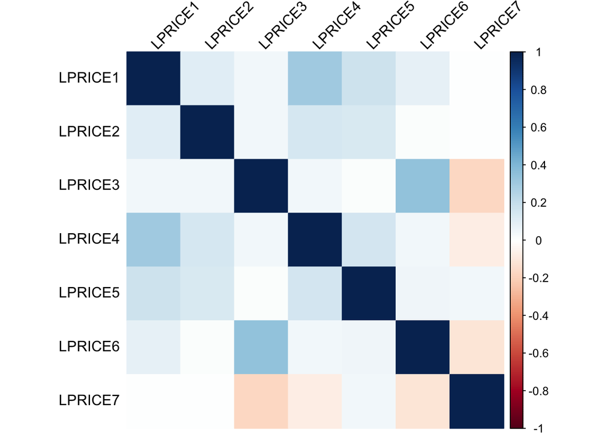

```r
# plot
cor_matrix <- cor(tuna[, grep("LPRICE", names(tuna))])
corrplot::corrplot(cor_matrix, method="color", tl.col="black", tl.srt=45)
```

```r
# actual correlation values
price_data <- tuna[, grep("LPRICE", names(tuna))]
cor_mat <- cor(price_data)
print(round(cor_mat, 3))
```

```
##         LPRICE1 LPRICE2 LPRICE3 LPRICE4 LPRICE5 LPRICE6 LPRICE7
## LPRICE1   1.000   0.102   0.048   0.304   0.177   0.085   0.003
## LPRICE2   0.102   1.000   0.049   0.141   0.130   0.013   0.005
## LPRICE3   0.048   0.049   1.000   0.042   0.017   0.349  -0.175
## LPRICE4   0.304   0.141   0.042   1.000   0.157   0.047  -0.072
## LPRICE5   0.177   0.130   0.017   0.157   1.000   0.053   0.045
## LPRICE6   0.085   0.013   0.349   0.047   0.053   1.000  -0.115
## LPRICE7   0.003   0.005  -0.175  -0.072   0.045  -0.115   1.000
```

```r
high_corr_pairs <- which(abs(cor_mat) > 0.7 & upper.tri(cor_mat), arr.ind = TRUE)
high_corr_pairs
```

```
##      row col
```

Simply with this, multicollinearity doesn’t seem like an issue… We’ll try VIF.

```r
library(car)
mod_for_vif <- lm(LPRICE1 ~ LPRICE2 + LPRICE3 + LPRICE4 + LPRICE5 + LPRICE6 + LPRICE7,
                  data = tuna)
vif(mod_for_vif)
```

```
##  LPRICE2  LPRICE3  LPRICE4  LPRICE5  LPRICE6  LPRICE7
## 1.035210 1.165992 1.048936 1.044186 1.146588 1.043773
```

# Market Share (MCI)

```r
n_brands <- 7

# market share
sales_cols <- paste0("MOVE", 1:n_brands)
for(i in 1:n_brands) {
  tuna[[paste0("share", i)]] <- tuna[[sales_cols[i]]] / tuna$FULLCUST
}
```

```r
# Log-transform the market shares and then log-center them.
for(i in 1:n_brands) {
  tuna[[paste0("log_share", i)]] <- log(tuna[[paste0("share", i)]])
}
```

```r
# Compute the average log share across all brands for each observation
tuna$avg_log_share <- rowMeans(tuna[, paste0("log_share", 1:n_brands)])
```

```r
# Create centered log share variables for each brand:
for(i in 1:n_brands) {
  tuna[[paste0("centered_log_share", i)]] <- tuna[[paste0("log_share", i)]] - tuna$avg_log_share
}
```

```r
# Step 3. Set up and run the MCI regression for each brand.
price_cols <- paste0("LPRICE", 1:n_brands)
tuna$avg_log_price <- rowMeans(tuna[, price_cols])


# log center price
for(i in 1:n_brands) {
  tuna[[paste0("centered_log_price", i)]] <- tuna[[paste0("LPRICE", i)]] - tuna$avg_log_price
}
```

```r
# Run separate regressions for each brand
models <- list()
for(i in 1:n_brands) {
  # CORRECTION
  # WRONG: JUST DID OWN-PRICE: formula_str <- paste0("centered_log_share", i, "~", "centered_log_price", i)
  formula_str <- paste0("centered_log_share", i, " ~ ",
                        paste0("centered_log_price", 1:n_brands, collapse = " + "))
  models[[i]] <- lm(as.formula(formula_str), data = tuna)

  cat("\n------ Summary for Brand", i, "------\n")
  print(summary(models[[i]]))
}
```

```
##
## ------ Summary for Brand 1 ------
##
## Call:
## lm(formula = as.formula(formula_str), data = tuna)
##
## Residuals:
##      Min       1Q   Median       3Q      Max
## -2.05427 -0.24373 -0.08775  0.13727  3.15859
##
## Coefficients: (1 not defined because of singularities)
##                     Estimate Std. Error t value Pr(>|t|)
## (Intercept)           1.4213     0.6809   2.087   0.0376 *
## centered_log_price1  -5.5686     0.3240 -17.187   <2e-16 ***
## centered_log_price2   0.1089     0.3262   0.334   0.7386
## centered_log_price3  -0.3376     0.6289  -0.537   0.5918
## centered_log_price4   0.6265     0.2930   2.138   0.0332 *
## centered_log_price5  -0.7213     0.6249  -1.154   0.2493
## centered_log_price6  -1.7851     0.8510  -2.097   0.0367 *
## centered_log_price7       NA         NA      NA       NA
## ---
## Signif. codes:  0 '***' 0.001 '**' 0.01 '*' 0.05 '.' 0.1 ' ' 1
##
## Residual standard error: 0.4791 on 331 degrees of freedom
## Multiple R-squared:  0.6149, Adjusted R-squared:  0.6079
## F-statistic: 88.07 on 6 and 331 DF,  p-value: < 2.2e-16
##
##
## ------ Summary for Brand 2 ------
##
## Call:
## lm(formula = as.formula(formula_str), data = tuna)
##
## Residuals:
##      Min       1Q   Median       3Q      Max
## -1.28593 -0.25304 -0.05639  0.15919  2.75737
##
## Coefficients: (1 not defined because of singularities)
##                     Estimate Std. Error t value Pr(>|t|)
## (Intercept)         -0.71270    0.66823  -1.067 0.286948
```

[output cut: 133 more lines]

```
##                     Estimate Std. Error t value Pr(>|t|)
## (Intercept)           2.0045     0.8082   2.480   0.0136 *
## centered_log_price1   3.4654     0.3846   9.011  < 2e-16 ***
## centered_log_price2   3.1192     0.3872   8.056 1.45e-14 ***
## centered_log_price3   4.6257     0.7465   6.196 1.72e-09 ***
## centered_log_price4   3.0045     0.3478   8.639 2.46e-16 ***
## centered_log_price5   3.1780     0.7418   4.284 2.40e-05 ***
## centered_log_price6  -0.2625     1.0101  -0.260   0.7951
## centered_log_price7       NA         NA      NA       NA
## ---
## Signif. codes:  0 '***' 0.001 '**' 0.01 '*' 0.05 '.' 0.1 ' ' 1
##
## Residual standard error: 0.5687 on 331 degrees of freedom
## Multiple R-squared:  0.2921, Adjusted R-squared:  0.2793
## F-statistic: 22.76 on 6 and 331 DF,  p-value: < 2.2e-16
```